# Boston Metropolitan Bicycle Mobility 4.0

### Importing the data table

After the connection is stablished, the data table can be imported as described. We decided to join the Bluebikes data on the start station for this report as there was no significant difference in the results compared to when joining on the end station.

```python
#Formulate Query
query = """select stations, trip_count, trip_not_subscriber, trip_subscriber,ZIPcode, latitude, longitude, venue_count, Art_Entertainment, College_University, Events, Food, NightlifeSpot, Outdoors_Recreation, Professional_OtherPlaces, Residence, Shop_Service, Travel_Transport  from
(select trip_count, trip_not_subscriber, trip_subscriber, stations, bbb.postalcode as postalcode from
(select count(boston_project.bluebike_station.id1) as stations, postalcode1
	from boston_project.bluebike_station group by postalcode1) as bbs
right join
(select trip_count, trip_not_subscriber, trip_subscriber, bbt.postalcode as postalcode from
(select count(bluebike.trip) as trip_count, bluebike.postalcode as postalcode
	from (select boston_project.bluebike_trip.id as trip, boston_project.bluebike_station.postalcode1 as postalcode from
		 boston_project.bluebike_trip join boston_project.bluebike_station
		 	on boston_project.bluebike_trip.start_station=boston_project.bluebike_station.id1) as bluebike
	group by bluebike.postalcode) as bbt
left join
(select trip_not_subscriber, trip_subscriber, bbc.postalcode as postalcode from
(select count(bluebike.trip) as trip_not_subscriber, bluebike.postalcode as postalcode
	from (select boston_project.bluebike_trip.id as trip, boston_project.bluebike_trip.usertype, boston_project.bluebike_station.postalcode1 as postalcode from
		 boston_project.bluebike_trip join boston_project.bluebike_station
		 	on boston_project.bluebike_trip.start_station=boston_project.bluebike_station.id1) as bluebike
 	where bluebike.usertype='Customer'
	group by bluebike.postalcode) as bbc
full join
(select count(bluebike.trip) as trip_subscriber, bluebike.postalcode as postalcode
	from (select boston_project.bluebike_trip.id as trip, boston_project.bluebike_trip.usertype, boston_project.bluebike_station.postalcode1 as postalcode from
		 boston_project.bluebike_trip join boston_project.bluebike_station
		 	on boston_project.bluebike_trip.start_station=boston_project.bluebike_station.id1) as bluebike
 	where bluebike.usertype='Subscriber'
	group by bluebike.postalcode) as bbs
on bbc.postalcode = bbs.postalcode) as bbu
on bbt.postalcode = bbu.postalcode) as bbb
on bbs.postalcode1 = bbb.postalcode) as bb
right join
-- Join 11
--Total
(select venue_count, Art_Entertainment, College_University, Events, Food, NightlifeSpot, Outdoors_Recreation, Professional_OtherPlaces, Residence, Shop_Service, Travel_Transport, ZIPcode, latitude, longitude from
(select count(boston_project.foursquare_venues.fsv_id) as venue_count, boston_project.foursquare_venues.postalcode as postalcode
 	from boston_project.foursquare_venues join boston_project.foursquare_categories
		on boston_project.foursquare_venues.category = boston_project.foursquare_categories.fs_id
 group by boston_project.foursquare_venues.postalcode) as venue
right join
-- Join 10
(select Art_Entertainment, College_University, Events, Food, NightlifeSpot, Outdoors_Recreation, Professional_OtherPlaces, Residence, Shop_Service, Travel_Transport, ZIPcode, latitude, longitude from
--Arts&Entertainment
(select count(boston_project.foursquare_venues.fsv_id) as Art_Entertainment, boston_project.foursquare_venues.postalcode as postalcode
 	from boston_project.foursquare_venues join boston_project.foursquare_categories
		on boston_project.foursquare_venues.category = boston_project.foursquare_categories.fs_id
	where boston_project.foursquare_categories.CAT_Level0 = 'Arts & Entertainment'
 group by boston_project.foursquare_venues.postalcode) as AE
right join
-- Join 9
(select College_University, Events, Food, NightlifeSpot, Outdoors_Recreation, Professional_OtherPlaces, Residence, Shop_Service, Travel_Transport, ZIPcode, latitude, longitude from
--College&University
(select count(boston_project.foursquare_venues.fsv_id) as College_University, boston_project.foursquare_venues.postalcode as postalcode
 	from boston_project.foursquare_venues join boston_project.foursquare_categories
		on boston_project.foursquare_venues.category = boston_project.foursquare_categories.fs_id
	where boston_project.foursquare_categories.CAT_Level0 = 'College & University'
 group by boston_project.foursquare_venues.postalcode) as CU
right join
-- Join 8
(select Events, Food, NightlifeSpot, Outdoors_Recreation, Professional_OtherPlaces, Residence, Shop_Service, Travel_Transport, ZIPcode, latitude, longitude from
--Event
(select count(boston_project.foursquare_venues.fsv_id) as Events, boston_project.foursquare_venues.postalcode as postalcode
 	from boston_project.foursquare_venues join boston_project.foursquare_categories
		on boston_project.foursquare_venues.category = boston_project.foursquare_categories.fs_id
	where boston_project.foursquare_categories.CAT_Level0 = 'Event'
 group by boston_project.foursquare_venues.postalcode) as EV
right join
-- Join 7
(select Food, NightlifeSpot, Outdoors_Recreation, Professional_OtherPlaces, Residence, Shop_Service, Travel_Transport, ZIPcode, latitude, longitude from
--Food
(select count(boston_project.foursquare_venues.fsv_id) as Food, boston_project.foursquare_venues.postalcode as postalcode
 	from boston_project.foursquare_venues join boston_project.foursquare_categories
		on boston_project.foursquare_venues.category = boston_project.foursquare_categories.fs_id
	where boston_project.foursquare_categories.CAT_Level0 = 'Food'
 group by boston_project.foursquare_venues.postalcode) as FD
right join
-- Join 6
(select NightlifeSpot, Outdoors_Recreation, Professional_OtherPlaces, Residence, Shop_Service, Travel_Transport, ZIPcode, latitude, longitude from
--NightlifeSpot
(select count(boston_project.foursquare_venues.fsv_id) as NightlifeSpot, boston_project.foursquare_venues.postalcode as postalcode
 	from boston_project.foursquare_venues join boston_project.foursquare_categories
		on boston_project.foursquare_venues.category = boston_project.foursquare_categories.fs_id
	where boston_project.foursquare_categories.CAT_Level0 = 'Nightlife Spot'
 group by boston_project.foursquare_venues.postalcode) as NS
right join
-- Join 5
(select Outdoors_Recreation, Professional_OtherPlaces, Residence, Shop_Service, Travel_Transport, ZIPcode, latitude, longitude from
--Outdoors&Recreation
(select count(boston_project.foursquare_venues.fsv_id) as Outdoors_Recreation, boston_project.foursquare_venues.postalcode as postalcode
 	from boston_project.foursquare_venues join boston_project.foursquare_categories
		on boston_project.foursquare_venues.category = boston_project.foursquare_categories.fs_id
	where boston_project.foursquare_categories.CAT_Level0 = 'Outdoors & Recreation'
 group by boston_project.foursquare_venues.postalcode) as ORc
right join
-- Join 4
(select Professional_OtherPlaces, Residence, Shop_Service, Travel_Transport, ZIPcode, latitude, longitude from
--Professional & Other Places
(select count(boston_project.foursquare_venues.fsv_id) as Professional_OtherPlaces, boston_project.foursquare_venues.postalcode as postalcode
 	from boston_project.foursquare_venues join boston_project.foursquare_categories
		on boston_project.foursquare_venues.category = boston_project.foursquare_categories.fs_id
	where boston_project.foursquare_categories.CAT_Level0 = 'Professional & Other Places'
 group by boston_project.foursquare_venues.postalcode) as PO
right join
-- Join 3
(select Residence, Shop_Service, Travel_Transport, ZIPcode, latitude, longitude from
--Residence
(select count(boston_project.foursquare_venues.fsv_id) as Residence, boston_project.foursquare_venues.postalcode as postalcode
 	from boston_project.foursquare_venues join boston_project.foursquare_categories
		on boston_project.foursquare_venues.category = boston_project.foursquare_categories.fs_id
	where boston_project.foursquare_categories.CAT_Level0 = 'Residence'
 group by boston_project.foursquare_venues.postalcode) as Res
right join
-- Join 2
(select Shop_Service, Travel_Transport, ZIPcode, latitude, longitude from
--Shop&Service
(select count(boston_project.foursquare_venues.fsv_id) as Shop_Service, boston_project.foursquare_venues.postalcode as postalcode
 	from boston_project.foursquare_venues join boston_project.foursquare_categories
		on boston_project.foursquare_venues.category = boston_project.foursquare_categories.fs_id
	where boston_project.foursquare_categories.CAT_Level0 = 'Shop & Service'
 group by boston_project.foursquare_venues.postalcode) as SS
right join
-- Join 1
 (select boston_project.postal_code.postalcode as ZIPcode, boston_project.postal_code.latitude as latitude, boston_project.postal_code.longitude as longitude , Travel_Transport from
--Travel&Transport
(select count(boston_project.foursquare_venues.fsv_id) as Travel_Transport, boston_project.foursquare_venues.postalcode as postalcode
 	from boston_project.foursquare_venues join boston_project.foursquare_categories
		on boston_project.foursquare_venues.category = boston_project.foursquare_categories.fs_id
	where boston_project.foursquare_categories.CAT_Level0 = 'Travel & Transport'
 group by boston_project.foursquare_venues.postalcode) as TT
right join
boston_project.postal_code
on TT.postalcode = boston_project.postal_code.postalcode) as J1
on SS.postalcode = J1.ZIPcode) as J2
on Res.postalcode = J2.ZIPcode) as J3
on PO.postalcode = J3.ZIPcode) as J4
on ORc.postalcode = J4.ZIPcode) as J5
on NS.postalcode = J5.ZIPcode) as J6
on FD.postalcode = J6.ZIPcode) as J7
on EV.postalcode = J7.ZIPcode) as J8
on CU.postalcode = J8.ZIPcode) as J9
on AE.postalcode = J9.ZIPcode) as J10
on venue.postalcode = J10.ZIPcode) as J11
on bb.postalcode = J11.ZIPcode
"""
# Execute Query
cur.execute(query)
CAT0 = ['Art_Entertainment', 'College_University', 'Events', 'Food', 'NightlifeSpot', 'Outdoors_Recreation', 'Professional_OtherPlaces', 'Residence', 'Shop_Service', 'Travel_Transport']
fs_bb_allzipcodes = pd.DataFrame(cur.fetchall(),columns=['stations','trip_count', 'trip_not_subscriber', 'trip_subscriber','ZIPcode','latitude', 'longitude', 'venue_count','Art_Entertainment', 'College_University', 'Events', 'Food', 'NightlifeSpot', 'Outdoors_Recreation', 'Professional_OtherPlaces', 'Residence', 'Shop_Service', 'Travel_Transport'])
conn.commit()
fs_bb_allzipcodes
```

|  | stations | trip_count | trip_not_subscriber | trip_subscriber | ZIPcode | latitude | longitude | venue_count | Art_Entertainment | College_University | Events | Food | NightlifeSpot | Outdoors_Recreation | Professional_OtherPlaces | Residence | Shop_Service | Travel_Transport |
| --- | --- | --- | --- | --- | --- | --- | --- | --- | --- | --- | --- | --- | --- | --- | --- | --- | --- | --- |
| 0 | 7.0 | 1358.0 | 1063.0 | 295.0 | 1970 | 42.514710 | -70.907524 | 17 | NaN | NaN | None | 6 | 1.0 | 2.0 | NaN | NaN | 6 | 2.0 |
| 1 | NaN | NaN | NaN | NaN | 1971 | 42.519500 | -70.897200 | 120 | 14.0 | NaN | None | 56 | 11.0 | 7.0 | NaN | NaN | 25 | 7.0 |
| 2 | 5.0 | 21011.0 | 9960.0 | 11051.0 | 2108 | 42.357323 | -71.064500 | 213 | 19.0 | NaN | None | 130 | 12.0 | 20.0 | 2.0 | NaN | 22 | 8.0 |
| 3 | 5.0 | 21265.0 | 10634.0 | 10631.0 | 2109 | 42.363243 | -71.053770 | 186 | 14.0 | NaN | None | 93 | 16.0 | 21.0 | 3.0 | NaN | 13 | 26.0 |
| 4 | 7.0 | 25986.0 | 11642.0 | 14344.0 | 2110 | 42.358162 | -71.054060 | 222 | 11.0 | NaN | None | 143 | 14.0 | 22.0 | 2.0 | NaN | 17 | 13.0 |
| ... | ... | ... | ... | ... | ... | ... | ... | ... | ... | ... | ... | ... | ... | ... | ... | ... | ... | ... |
| 79 | 6.0 | 3721.0 | 1529.0 | 2192.0 | 2474 | 42.417190 | -71.161110 | 60 | 4.0 | NaN | None | 30 | NaN | 6.0 | 1.0 | NaN | 19 | NaN |
| 80 | NaN | NaN | NaN | NaN | 2476 | 42.415130 | -71.176620 | 15 | 1.0 | NaN | None | 6 | NaN | 5.0 | NaN | NaN | 3 | NaN |
| 81 | NaN | NaN | NaN | NaN | 2477 | 42.370800 | -71.183300 | 59 | NaN | NaN | None | 32 | 2.0 | 11.0 | NaN | NaN | 13 | 1.0 |
| 82 | 1.0 | 1131.0 | 422.0 | 709.0 | 2478 | 42.395500 | -71.182106 | 28 | NaN | NaN | None | 18 | NaN | 4.0 | NaN | NaN | 6 | NaN |
| 83 | NaN | NaN | NaN | NaN | 2495 | 42.336700 | -71.209400 | 15 | NaN | NaN | None | 7 | NaN | 2.0 | NaN | NaN | 6 | NaN |

84 rows × 18 columns

## Analysis

This analysis is split in three parts:

- Inspection of the data
- Analysis of the total trips
- Analysis of the subscribers and non-subscribers trips

### Inspection of the data

The source data consists of **9,193 venues**, **978,710 trips** and **409 bike stations** spread over **84 zip codes**. The number of data points allows us to comfortably perform the analysis and detect general trends.

In order to understand the data, with possible trends to formulate the initial modeling hypothesis, we created some cross-plots. Those are the cross-plots between count of venues and count of trips, count of stations and count of trips and the count of stations and count of venues. For each of those charts, each data point is an aggregation of the data into a ZIP code.

```
No handles with labels found to put in legend.
```

```
Graph 1
```

```
<function matplotlib.pyplot.show(close=None, block=None)>
```

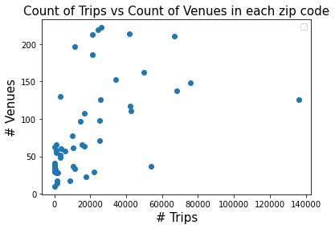

```python
print("Graph 1")
plt.scatter(fs_bb_allzipcodes["trip_count"],fs_bb_allzipcodes["venue_count"])
plt.legend()
plt.xlabel('# Trips', fontsize = 15)
plt.ylabel('# Venues', fontsize = 15)
plt.title('Count of Trips vs Count of Venues in each zip code', fontsize = 15)
plt.show
```

```
No handles with labels found to put in legend.
```

```
Graph 2
```

```
<function matplotlib.pyplot.show(close=None, block=None)>
```

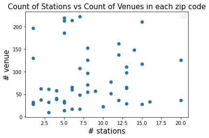

```python
print("Graph 2")
plt.scatter(fs_bb_allzipcodes["stations"],fs_bb_allzipcodes["venue_count"])
plt.legend()
plt.xlabel('# stations', fontsize = 15)
plt.ylabel('# venue', fontsize = 15)
plt.title('Count of Stations vs Count of Venues in each zip code', fontsize = 15)
plt.show
```

```
Graph 3
```

```
No handles with labels found to put in legend.
```

```
<function matplotlib.pyplot.show(close=None, block=None)>
```

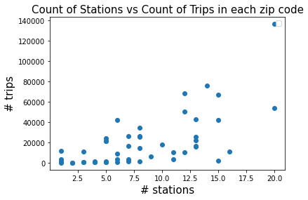

```python
print("Graph 3")
plt.scatter(fs_bb_allzipcodes["stations"],fs_bb_allzipcodes["trip_count"])
plt.legend()
plt.xlabel('# stations', fontsize = 15)
plt.ylabel('# trips', fontsize = 15)
plt.title('Count of Stations vs Count of Trips in each zip code', fontsize = 15)
plt.show
```

```python
print("Table 1")
inital_corr = fs_bb_allzipcodes[['stations', 'trip_count','venue_count']]
inital_corr.corr()
```

```
Table 1
```

|  | stations | trip_count | venue_count |
| --- | --- | --- | --- |
| stations | 1.000000 | 0.660066 | 0.088817 |
| trip_count | 0.660066 | 1.000000 | 0.519368 |
| venue_count | 0.088817 | 0.519368 | 1.000000 |

### Analysis of the total trips

To understand if the concentration of any specific type of venue has a stronger correlation with the trip, the count of each type of venue was plotted against the number of trips and the correlation matrix was calculated.

```
Graph 4
```

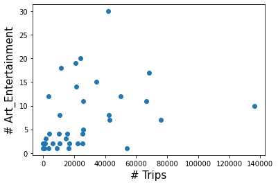

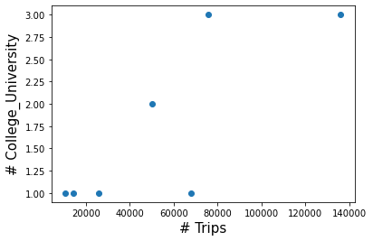

[figure not shown]

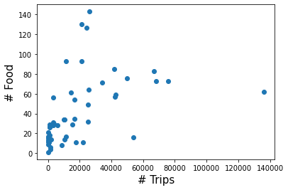

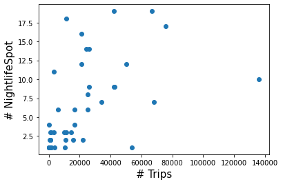

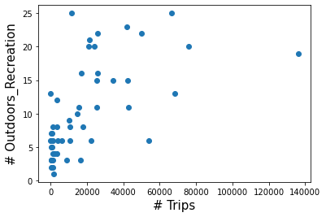

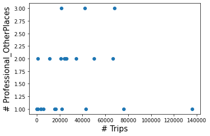

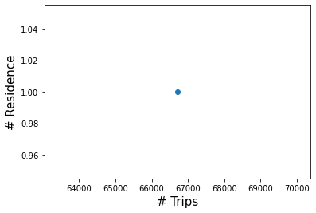

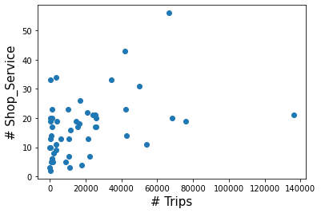

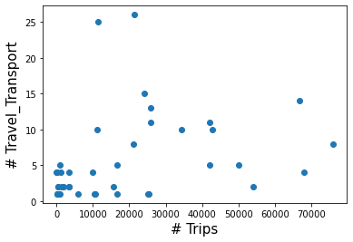

```python
print("Graph 4")
for i in range(0,len(CAT0)):
    plt.scatter(fs_bb_allzipcodes["trip_count"], fs_bb_allzipcodes[CAT0[i]])
    plt.xlabel('# Trips', fontsize = 15)
    plt.ylabel('# '+str(CAT0[i]), fontsize = 15)
    plt.show()
```

```python
print("Table 2")
trip_venue_types = fs_bb_allzipcodes[['stations','trip_count','Art_Entertainment', 'College_University', 'Events', 'Food', 'NightlifeSpot', 'Outdoors_Recreation', 'Professional_OtherPlaces', 'Residence', 'Shop_Service', 'Travel_Transport']]

trip_venue_types.corr()
```

```
Table 2
```

|  | stations | trip_count | Art_Entertainment | College_University | Food | NightlifeSpot | Outdoors_Recreation | Professional_OtherPlaces | Residence | Shop_Service | Travel_Transport |
| --- | --- | --- | --- | --- | --- | --- | --- | --- | --- | --- | --- |
| stations | 1.000000 | 0.660066 | -0.098418 | 0.813435 | 0.081956 | 0.089577 | 0.178308 | -0.081101 | NaN | 0.119714 | -0.114605 |
| trip_count | 0.660066 | 1.000000 | 0.363881 | 0.802098 | 0.470166 | 0.520157 | 0.594149 | 0.173255 | NaN | 0.395844 | 0.307904 |
| Art_Entertainment | -0.098418 | 0.363881 | 1.000000 | 0.095979 | 0.800275 | 0.825982 | 0.646774 | 0.451214 | NaN | 0.264050 | 0.656209 |
| College_University | 0.813435 | 0.802098 | 0.095979 | 1.000000 | 0.161471 | 0.571194 | 0.558620 | -0.559017 | NaN | 0.177736 | 0.170389 |
| Food | 0.081956 | 0.470166 | 0.800275 | 0.161471 | 1.000000 | 0.886112 | 0.724697 | 0.049738 | NaN | 0.215279 | 0.884053 |
| NightlifeSpot | 0.089577 | 0.520157 | 0.825982 | 0.571194 | 0.886112 | 1.000000 | 0.771565 | 0.214098 | NaN | 0.238974 | 0.820876 |
| Outdoors_Recreation | 0.178308 | 0.594149 | 0.646774 | 0.558620 | 0.724697 | 0.771565 | 1.000000 | 0.371545 | NaN | 0.406964 | 0.598275 |
| Professional_OtherPlaces | -0.081101 | 0.173255 | 0.451214 | -0.559017 | 0.049738 | 0.214098 | 0.371545 | 1.000000 | NaN | 0.303442 | -0.201165 |
| Residence | NaN | NaN | NaN | NaN | NaN | NaN | NaN | NaN | NaN | NaN | NaN |
| Shop_Service | 0.119714 | 0.395844 | 0.264050 | 0.177736 | 0.215279 | 0.238974 | 0.406964 | 0.303442 | NaN | 1.000000 | -0.070376 |
| Travel_Transport | -0.114605 | 0.307904 | 0.656209 | 0.170389 | 0.884053 | 0.820876 | 0.598275 | -0.201165 | NaN | -0.070376 | 1.000000 |

The charts and the correlation matrix clearly show that some types of venues have a stronger relationship with trips and others. However, just looking at the correlation matrix can be misleading for this analysis as venues that show stronger correlation are not necessarily wide spread throughout the city and thus using it can lead to reducing the scope of bluebikes instead of moving towards making it more accessible. To assess this, a coverage list was calculated to see what percentage of the zip codes that trips also had each type of venue.

```python
print("Table 3")
coverage = []
for i in range(0,len(CAT0)):
    coverage.append(fs_bb_allzipcodes[fs_bb_allzipcodes['trip_count'].notnull()][CAT0[i]].count()/fs_bb_allzipcodes[fs_bb_allzipcodes['trip_count'].notnull()]['trip_count'].count())

DC = {'CAT':CAT0, 'Coverage': coverage}
All_trips_Coverage = pd.DataFrame(DC)
All_trips_Coverage
```

```
Table 3
```

|  | CAT | Coverage |
| --- | --- | --- |
| 0 | Art_Entertainment | 0.745098 |
| 1 | College_University | 0.137255 |
| 2 | Events | 0.000000 |
| 3 | Food | 1.000000 |
| 4 | NightlifeSpot | 0.843137 |
| 5 | Outdoors_Recreation | 0.980392 |
| 6 | Professional_OtherPlaces | 0.490196 |
| 7 | Residence | 0.019608 |
| 8 | Shop_Service | 1.000000 |
| 9 | Travel_Transport | 0.784314 |

From the analysis so far, we narrow the types of venues to ‘Food’, ‘Night Life Sports’ and ‘Outdoors & Recreation’ as those are present in most places and have a relevant relationship with the number of trips.

**Modeling over the relevant venues**

To verify which areas are overserved and underserved we ran a liner regression using the number of stations as target variable with the number of trips and number of the selected venues as the independent variables.

```python
fs_bb_allzipcodes['FNO'] = fs_bb_allzipcodes['Food'].fillna(0)+fs_bb_allzipcodes['NightlifeSpot'].fillna(0)+fs_bb_allzipcodes['Outdoors_Recreation'].fillna(0)

regr_station_FNO = linear_model.LinearRegression()
regr_station_FNO_data = fs_bb_allzipcodes[['stations','trip_count','FNO']].dropna()
x = regr_station_FNO_data[['trip_count','FNO']]
y = regr_station_FNO_data[['stations']]
regr_station_FNO.fit(x,y)
regr_station_FNO.score(x,y)
```

```
0.5141170131253688
```

```python
fs_bb_allzipcodes['trip_count'] = fs_bb_allzipcodes['trip_count'].fillna(0)
fs_bb_allzipcodes['station_pred'] = regr_station_FNO.predict(fs_bb_allzipcodes[['trip_count','FNO']])
fs_bb_allzipcodes['station_pred'] = fs_bb_allzipcodes['station_pred'].round(2)
fs_bb_allzipcodes[['station_pred','stations','trip_count','Food','NightlifeSpot','Outdoors_Recreation']]
```

|  | station_pred | stations | trip_count | Food | NightlifeSpot | Outdoors_Recreation |
| --- | --- | --- | --- | --- | --- | --- |
| 0 | 6.87 | 7.0 | 1358.0 | 6 | 1.0 | 2.0 |
| 1 | 4.34 | NaN | 0.0 | 56 | 11.0 | 7.0 |
| 2 | 4.59 | 5.0 | 21011.0 | 130 | 12.0 | 20.0 |
| 3 | 5.76 | 5.0 | 21265.0 | 93 | 16.0 | 21.0 |
| 4 | 4.78 | 7.0 | 25986.0 | 143 | 14.0 | 22.0 |
| ... | ... | ... | ... | ... | ... | ... |
| 79 | 6.29 | 6.0 | 3721.0 | 30 | NaN | 6.0 |
| 80 | 6.58 | NaN | 0.0 | 6 | NaN | 5.0 |
| 81 | 5.37 | NaN | 0.0 | 32 | 2.0 | 11.0 |
| 82 | 6.37 | 1.0 | 1131.0 | 18 | NaN | 4.0 |
| 83 | 6.65 | NaN | 0.0 | 7 | NaN | 2.0 |

84 rows × 6 columns

The results were then placed in a cluster and mapped to easily visualize which ones are underserved and overserved.

```python
print("Figure 1")

# Labeling the zip codes
lst = []
for i in range(0,len(fs_bb_allzipcodes)):
    if fs_bb_allzipcodes['stations'][i]>fs_bb_allzipcodes['station_pred'][i]:
        lst.append(1)
    else:
        lst.append(0)
fs_bb_allzipcodes['Cluster_allTrips'] = pd.DataFrame(lst)

# Generating map with results
latitude = fs_bb_allzipcodes['latitude'].mean()
longitude = fs_bb_allzipcodes['longitude'].mean()
rainbow = ['#8000ff', '#ff0000']
map_clusters = folium.Map(location=[latitude, longitude], zoom_start=11)

for lat, lon,station, Pred_stat, fno, trip, zipcode, cluster in zip(fs_bb_allzipcodes['latitude'], fs_bb_allzipcodes['longitude'], fs_bb_allzipcodes['stations'], fs_bb_allzipcodes['station_pred'], fs_bb_allzipcodes['FNO'], fs_bb_allzipcodes['trip_count'], fs_bb_allzipcodes['ZIPcode'], fs_bb_allzipcodes['Cluster_allTrips']):
    label = folium.Popup('Stations '+str(station)+'\n' +
                         'Predicted '+str(Pred_stat)+'\n' +
                         'Trips '+str(trip)+'\n' +
                         'Venues '+str(fno)+'\n' +
                         'ZIP Code '+str(zipcode)+'\n' +
                         '\nCluster ' + str(cluster), parse_html=True)
    folium.CircleMarker(
        [lat, lon],
        radius=10,
        popup=label,
        color=rainbow[cluster-1],
        fill=True,
        fill_color=rainbow[cluster-1],
        fill_opacity=0.7).add_to(map_clusters)

map_clusters
```

```
Figure 1
```

Make this Notebook Trusted to load map: File -> Trust Notebook

[interactive chart not shown]

As presented in the map, the areas close to downtown are generally overserved while the area in the suburbs are underserved.

### Analysis of subscribers & non-subscribers trips

Similar analysis was performed with the trip broken down between subscribers and non-subcribers. As shown below the results differ slightly from the previous analysis.

```python
#Modeling over the relevant venues over subscribers trips
regr_station_FNO_S = linear_model.LinearRegression()
regr_station_FNO_S_data = fs_bb_allzipcodes[['stations','trip_subscriber','FNO']].dropna()
xss = regr_station_FNO_S_data[['trip_subscriber','FNO']]
yss = regr_station_FNO_S_data[['stations']]
regr_station_FNO_S.fit(xss,yss)
regr_station_FNO_S.score(xss,yss)
```

```
0.4580640183300886
```

```python
fs_bb_allzipcodes['trip_subscriber'] = fs_bb_allzipcodes['trip_subscriber'].fillna(0)
fs_bb_allzipcodes['station_S_pred'] = regr_station_FNO_S.predict(fs_bb_allzipcodes[['trip_subscriber','FNO']])
fs_bb_allzipcodes['station_S_pred'] = fs_bb_allzipcodes['station_S_pred'].round(2)
fs_bb_allzipcodes[['station_S_pred','stations','trip_subscriber','Food','NightlifeSpot','Outdoors_Recreation']]
```

|  | station_S_pred | stations | trip_subscriber | Food | NightlifeSpot | Outdoors_Recreation |
| --- | --- | --- | --- | --- | --- | --- |
| 0 | 6.83 | 7.0 | 295.0 | 6 | 1.0 | 2.0 |
| 1 | 5.10 | NaN | 0.0 | 56 | 11.0 | 7.0 |
| 2 | 4.98 | 5.0 | 11051.0 | 130 | 12.0 | 20.0 |
| 3 | 5.72 | 5.0 | 10631.0 | 93 | 16.0 | 21.0 |
| 4 | 5.18 | 7.0 | 14344.0 | 143 | 14.0 | 22.0 |
| ... | ... | ... | ... | ... | ... | ... |
| 79 | 6.50 | 6.0 | 2192.0 | 30 | NaN | 6.0 |
| 80 | 6.72 | NaN | 0.0 | 6 | NaN | 5.0 |
| 81 | 5.84 | NaN | 0.0 | 32 | 2.0 | 11.0 |
| 82 | 6.58 | 1.0 | 709.0 | 18 | NaN | 4.0 |
| 83 | 6.77 | NaN | 0.0 | 7 | NaN | 2.0 |

84 rows × 6 columns

```python
print("Figure 2")
# Labeling the zip codes
lst = []
for i in range(0,len(fs_bb_allzipcodes)):
    if fs_bb_allzipcodes['stations'][i]>fs_bb_allzipcodes['station_S_pred'][i]:
        lst.append(1)
    else:
        lst.append(0)
fs_bb_allzipcodes['Cluster_SubsTrips'] = pd.DataFrame(lst)

# Generating map with results
map_clusters2 = folium.Map(location=[latitude, longitude], zoom_start=11)

for lat, lon,station, Pred_stat, fno, trip, zipcode, cluster in zip(fs_bb_allzipcodes['latitude'], fs_bb_allzipcodes['longitude'], fs_bb_allzipcodes['stations'], fs_bb_allzipcodes['station_S_pred'], fs_bb_allzipcodes['FNO'], fs_bb_allzipcodes['trip_subscriber'], fs_bb_allzipcodes['ZIPcode'], fs_bb_allzipcodes['Cluster_SubsTrips']):
    label = folium.Popup('Stations '+str(station)+'\n' +
                         'Predicted '+str(Pred_stat)+'\n' +
                         'Trips '+str(trip)+'\n' +
                         'Venues '+str(fno)+'\n' +
                         'ZIP Code '+str(zipcode)+'\n' +
                         '\nCluster ' + str(cluster), parse_html=True)
    folium.CircleMarker(
        [lat, lon],
        radius=10,
        popup=label,
        color=rainbow[cluster-1],
        fill=True,
        fill_color=rainbow[cluster-1],
        fill_opacity=0.7).add_to(map_clusters2)

map_clusters2
```

```
Figure 2
```

Make this Notebook Trusted to load map: File -> Trust Notebook

[interactive chart not shown]

```python
#Modeling over the relevant venues over non-subscribers trips
regr_station_FNO_NS = linear_model.LinearRegression()
regr_station_FNO_NS_data = fs_bb_allzipcodes[['stations','trip_not_subscriber','FNO']].dropna()
xns = regr_station_FNO_NS_data[['trip_not_subscriber','FNO']]
yns = regr_station_FNO_NS_data[['stations']]
regr_station_FNO_NS.fit(xns,yns)
regr_station_FNO_NS.score(xns,yns)
```

```
0.5007088173769747
```

```python
fs_bb_allzipcodes['trip_not_subscriber'] = fs_bb_allzipcodes['trip_not_subscriber'].fillna(0)
fs_bb_allzipcodes['station_NS_pred'] = regr_station_FNO_NS.predict(fs_bb_allzipcodes[['trip_not_subscriber','FNO']])
fs_bb_allzipcodes['station_NS_pred'] = fs_bb_allzipcodes['station_NS_pred'].round(2)
fs_bb_allzipcodes[['station_NS_pred','stations','trip_not_subscriber','Food','NightlifeSpot','Outdoors_Recreation']]
```

|  | station_NS_pred | stations | trip_not_subscriber | Food | NightlifeSpot | Outdoors_Recreation |
| --- | --- | --- | --- | --- | --- | --- |
| 0 | 7.20 | 7.0 | 1063.0 | 6 | 1.0 | 2.0 |
| 1 | 3.47 | NaN | 0.0 | 56 | 11.0 | 7.0 |
| 2 | 5.06 | 5.0 | 9960.0 | 130 | 12.0 | 20.0 |
| 3 | 6.98 | 5.0 | 10634.0 | 93 | 16.0 | 21.0 |
| 4 | 5.23 | 7.0 | 11642.0 | 143 | 14.0 | 22.0 |
| ... | ... | ... | ... | ... | ... | ... |
| 79 | 6.18 | 6.0 | 1529.0 | 30 | NaN | 6.0 |
| 80 | 6.49 | NaN | 0.0 | 6 | NaN | 5.0 |
| 81 | 4.86 | NaN | 0.0 | 32 | 2.0 | 11.0 |
| 82 | 6.21 | 1.0 | 422.0 | 18 | NaN | 4.0 |
| 83 | 6.58 | NaN | 0.0 | 7 | NaN | 2.0 |

84 rows × 6 columns

```python
print("Figure 3")
# Labeling the zip codes
lst = []
for i in range(0,len(fs_bb_allzipcodes)):
    if fs_bb_allzipcodes['stations'][i]>fs_bb_allzipcodes['station_NS_pred'][i]:
        lst.append(1)
    else:
        lst.append(0)
fs_bb_allzipcodes['Cluster_Non_SubsTrips'] = pd.DataFrame(lst)

# Generating map with results
map_clusters3 = folium.Map(location=[latitude, longitude], zoom_start=11)
for lat, lon,station, Pred_stat, fno, trip, zipcode, cluster in zip(fs_bb_allzipcodes['latitude'], fs_bb_allzipcodes['longitude'], fs_bb_allzipcodes['stations'], fs_bb_allzipcodes['station_NS_pred'], fs_bb_allzipcodes['FNO'], fs_bb_allzipcodes['trip_not_subscriber'], fs_bb_allzipcodes['ZIPcode'], fs_bb_allzipcodes['Cluster_Non_SubsTrips']):
    label = folium.Popup('Stations '+str(station)+'\n' +
                         'Predicted '+str(Pred_stat)+'\n' +
                         'Trips '+str(trip)+'\n' +
                         'Venues '+str(fno)+'\n' +
                         'ZIP Code '+str(zipcode)+'\n' +
                         '\nCluster ' + str(cluster), parse_html=True)
    folium.CircleMarker(
        [lat, lon],
        radius=10,
        popup=label,
        color=rainbow[cluster-1],
        fill=True,
        fill_color=rainbow[cluster-1],
        fill_opacity=0.7).add_to(map_clusters3)

map_clusters3
```

```
Figure 3
```

Make this Notebook Trusted to load map: File -> Trust Notebook

[interactive chart not shown]

# References

1. How Massachusetts plans to become more bike-friendly: https://www.boston.com/news/local-news/2019/01/10/massachusetts-plans-more-bike-friendly/
2. Boston's vision for equitable bike share: https://betterbikeshare.org/2021/05/18/bostons-vision-for-equitable-bike-share/
3. Mobility 4.0: https://medium.com/assembly-ventures/towards-mobility-4-0-759e414ab397
4. Industrial revolution 4.0: https://www.thedualarity.com/industrial-revolution-4-0-2/
5. Urban mobility at a tipping point: https://www.mckinsey.com/business-functions/sustainability/our-insights/urban-mobility-at-a-tipping-point

# Acknowledgements

First and foremost, we would like to thank our Professor- Gittu George who guided us in doing this project. He provided us with invaluable advice and helped us in difficult periods. His motivation and help contributed tremendously to the successful completion of the project.

Besides, we would like to thank all the Teaching Assistants specially Colby DeLisle, who helped us by giving us useful feedback and supported our learning throughout the period.

# Appendix

**Figure 1**

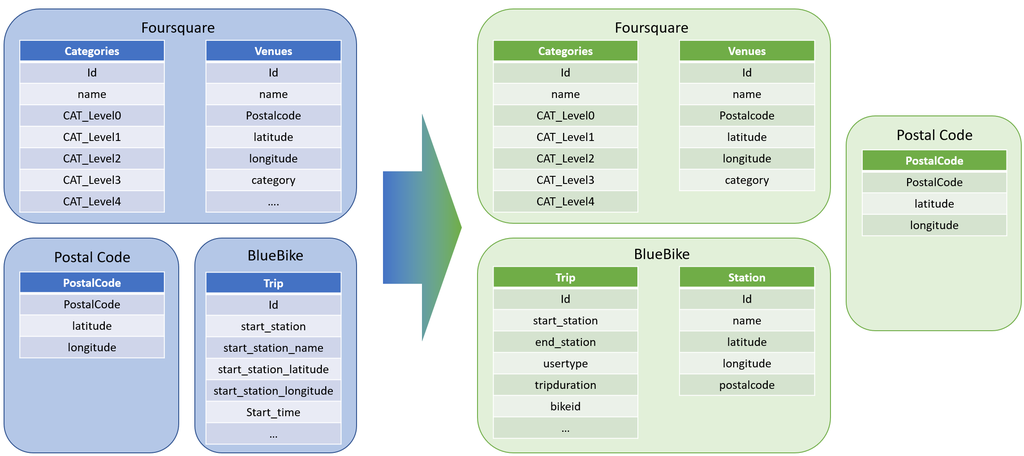